# HW1

2024-04-08

Q0 A: My name is Ruyue Wang and my preferred name is Jasmine.

Q0 B: I have read and understood the entire syllabus.

Q0 C: I took 515, 514 at UW which are related to R coding. I’m familiar with using R studio, but some online sources are needed while trying to solve some problems.

Q0 D: I hope I can get more familiar and confident while using R in the future.

Q2 A: The function generate_data takes a single integer argument n, representing the number of data points to generate. It ensures that n is a positive integer. It then generates a vector sample_vec of length n, where each element is sampled from one of three distributions based on the values in the vector idx_vec, which is sampled from a uniform distribution over {1, 2, 3}. Specifically, elements with value 1 are sampled from a normal distribution with mean 10 and standard deviation 1, elements with value 2 are sampled from a gamma distribution with shape parameter 2 and scale parameter 2, and elements with value 3 are sampled from a chi-squared distribution with 3 degrees of freedom. The function returns the resulting vector sample_vec.

Q2 B:

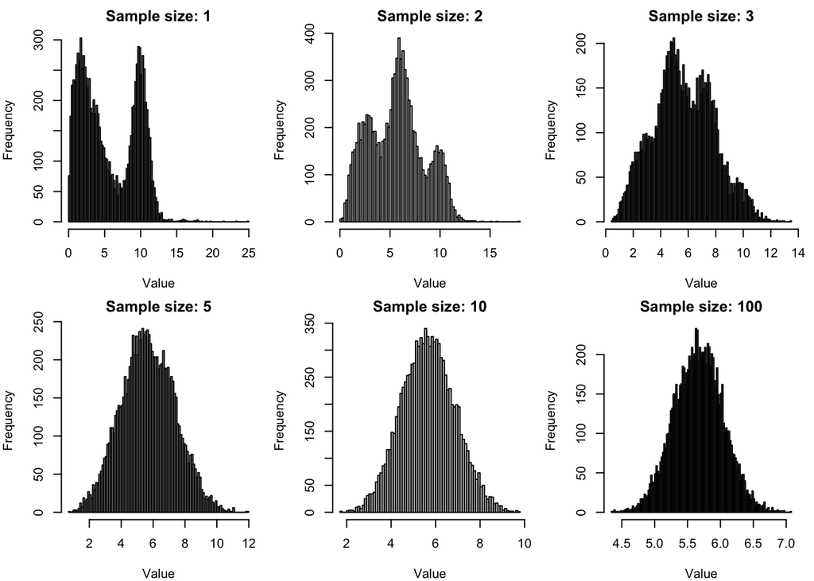

Q2 C: The histograms visually demonstrate the Central Limit Theorem by showing that as the sample size increases, the distribution of the sample means approaches a normal distribution, regardless of the underlying distribution of the data, which is evidenced by the increasingly bell-shaped curves as the sample size grows from 1 to 100.

Q3 B: dim() function can be used to print out the dimensionality of df. The class of df is shown as.

```
## [1] "data.frame"
```

which shows as the data.frame

Ensure the data frame is correctly loaded and displayed.

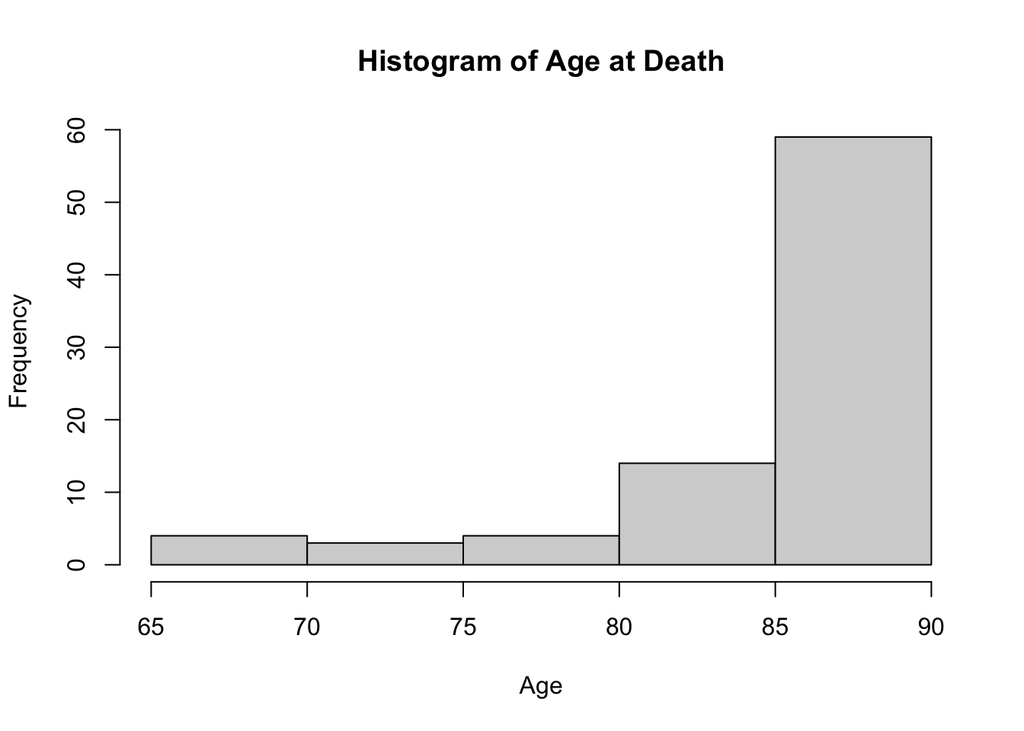

Q3 D:

```
## 'data.frame':    84 obs. of  7 variables:
##  $ Donor.ID        : chr  "H19.33.004" "H20.33.001" "H20.33.002" "H20.33.004" ...
##  $ Age.at.Death    : num  80 82 90 86 90 90 90 90 90 82 ...
##  $ Sex             : Factor w/ 2 levels "Female","Male": 1 2 1 2 1 1 1 1 2 1 ...
##  $ APOE4.Status    : Factor w/ 2 levels "N","Y": 1 1 1 2 1 2 2 1 1 1 ...
##  $ Cognitive.Status: Factor w/ 2 levels "Dementia","No dementia": 2 2 2 1 2 2 1 2 2 2 ...
##  $ Last.CASI.Score : int  85 97 93 80 94 92 79 98 93 NA ...
##  $ Braak           : Factor w/ 6 levels "Braak 0","Braak II",..: 4 4 4 5 4 5 5 3 4 4 ...
```

```
##    Donor.ID          Age.at.Death       Sex     APOE4.Status
##  Length:84          Min.   :65.00   Female:51   N:59
##  Class :character   1st Qu.:83.75   Male  :33   Y:25
##  Mode  :character   Median :90.00
##                     Mean   :86.26
##                     3rd Qu.:90.00
##                     Max.   :90.00
##
##     Cognitive.Status Last.CASI.Score       Braak
##  Dementia   :42      Min.   :66.00   Braak 0  : 2
##  No dementia:42      1st Qu.:80.00   Braak II : 4
##                      Median :89.00   Braak III: 6
##                      Mean   :87.32   Braak IV :23
##                      3rd Qu.:95.00   Braak V  :34
##                      Max.   :99.00   Braak VI :15
##                      NA's   :15
```

Q3 E: The summary in Question 3E is more informative because it provides specific counts and distributions for categorical variables and detailed statistics for numerical variables, allowing for a clearer understanding of the dataset’s characteristics and any potential imbalances or outliers

Q3 F:

```
##
##             Dementia No dementia
##   Braak 0          0           2
##   Braak II         2           2
##   Braak III        2           4
##   Braak IV         4          19
##   Braak V         20          14
##   Braak VI        14           1
```

Q3 G:

```
##
##                Dementia No dementia
##   1st Quartile       17           1
##   2nd Quartile       10           8
##   3rd Quartile        2          15
##   4th Quartile        3          13
```

The table shows that higher Last.CASI.Scores, which fall into the 3rd and 4th quartiles, are predominantly associated with “No dementia,” indicating that higher cognitive scores might be linked to lower instances of dementia. Conversely, the majority of “Dementia” cases are concentrated in the 1st quartile, suggesting that lower scores are strongly correlated with higher occurrences of dementia.